# Using the xtractomatic routines

Cara Wilson and Roy Mendelssohn

2016-07-25

## Introduction

`xtractomatic` is an R package developed to subset and extract satellite and other oceanographic related data from a remote server. The program can extract data for a moving point in time along a user-supplied set of longitude, latitude and time points; in a 3D bounding box; or within a polygon (through time). The `xtractomatic` functions were originally developed for the marine biology tagging community, to match up environmental data available from satellites (sea-surface temperature, sea-surface chlorophyll, sea-surface height, sea-surface salinity, vector winds) to track data from various tagged animals or shiptracks (`xtracto`). The package has since been extended to include the routines that extract data a 3D bounding box (`xtracto_3D`) or within a polygon (`xtractogon`). The `xtractomatic` package accesses data that are served through the ERDDAP (Environmental Research Division Data Access Program) server at the NOAA/SWFSC Environmental Research Division in Santa Cruz, California. The ERDDAP server can also be directly accessed at http://coastwatch.pfeg.noaa.gov/erddap. ERDDAP is a simple to use yet powerful web data service developed by Bob Simons.

This is the third version of `xtractomatic`. The original version was created by Dave Foley for Matlab and was modified for R by Cindy Bessey and Dave Foley. That version used a precurser to ERDDAP called BobDAP. BobDAP was less flexible and provided access to fewer datasets than does ERDDAP. The second version of xtractomatic was written by Roy Mendelssohn to use ERDDAP rather than BobDAP. This version, also written by Roy Mendelssohn, has many improvements including access to many more datasets, improved speed, better error checking, and crude search capabilites, and is the first version as a true R package.

### If you have used xtractomatic before

If you have existing R code that uses older versions of the `xtractomatic` functions, the code will likely require some simple and straightforward modifications to be used with this version. See the section What has Changed and Steps Going Forward

### The Main xtractomatic functions

There are three main data extraction functions in the `xtractomatic` package:

- `xtracto <- function(xpos, ypos, tpos, dtype, xlen, ylen, verbose=FALSE)`
- `xtracto_3D <- function(xpos, ypos, tpos, dtype, verbose=FALSE)`
- `xtractogon <- function(xpos, ypos, tpos, dtype, verbose=FALSE)`

There also are two information functions in the `xtractomatic` package:

- `searchData <- function(searchList=list(list("varname","chl")))`
- `getInfo <- function(dtype)`

The `dtype` parameter in the data extraction routines specifies a combination of which dataset on the ERDDAP server to access, and as well as which parameter from that dataset. The first sections demonstrate how to use these functions in realistic settings. The Selecting a dataset section shows how to find the `dtype` or other parameters of interest from the available datasets.

## Setting up

`xtractomatic` uses the `httr`, `ncdf4` and `sp` packages, and these packages must be installed first or `xtractomatic` will fail to install.

```r
install.packages("httr", dependencies = TRUE)
install.packages("ncdf4",dependencies = TRUE)
install.packages("sp", dependencies = TRUE)
```

The `xtractomatic` package is not available through CRAN at the moment, but it is available from [Github](https://github.com/rmendels/xtractomatic)

To install the `xtractomatic` package from Github ,

```r
install.packages("devtools")
devtools::install_github("rmendels/xtractomatic")
```

Once installed, to use `xtractomatic` do

```r
library("xtractomatic")
```

If the other libraries (`httr`, `ncdf4`, and `sp`) have been installed they will be found and do not need to be explicitly loaded.

### Using the R code examples

Besides the `xtractomatic` packages, the examples below depend on `ggplot2`, `ggfortify`, `lubridate`, `mapdata`, `RColorBrewer`, `reshape2`,and `xts`. These can be loaded beforehand (assuming they have been installed):

```r
library("ggplot2")
library("ggfortify")
library("lubridate")
library("mapdata")
library("RColorBrewer")
library("reshape2")
library("xts")
```

In order that the code snippets can be more stand-alone, the needed libraries are always `required` in the examples. It should be emphasized that these other packages are used to manipulate and plot the data in R, other packages could be used as well. The use of `xtractomatic` does not depend on these other packages.

There are also several R functions defined within the document that are used in other code examples. These include `mapFrame`, `plotFrame`, `chlaAvg`, `upwell`, and `plotUpwell`.

The plots use `ggplot2`. A basic tutorial on `ggplot2` is given by Dr. Eric Anderson of the National Marine Fisheries Service at [ggplot2_lecture1](http://eriqande.github.io/rep-res-web/lectures/ggplot_1_pole_vault_example.html#ggplot2-intro-lecture) and [ggplot2_lecture2](http://eriqande.github.io/rep-res-web/lectures/ggplot_2_reshape_facets_stats.html#ggplot2-second-lecture). There also is the tutorial at [ggplot2_Handout](http://www.ceb-institute.org/bbs/wp-content/uploads/2011/09/handout_ggplot2.pdf) though it is getting a little dated for some features of `ggplot2`. Anderson also has a simple [guide to maps in R](http://eriqande.github.io/rep-res-web/lectures/making-maps-with-R.html#map-making-in-R), other guides on making maps using `ggplot2` include [spatial.ly](http://spatial.ly/2013/12/introduction-spatial-data-ggplot2/) and [zevross](http://zevross.com/blog/2014/07/16/mapping-in-r-using-the-ggplot2-package/). Eric Anderson also has a [nice page](http://eriqande.github.io/2014/12/24/plotting-sst-with-ggplot.html) on combining raster data with maps using `ggplot2`.

## Getting Started

### An xtracto example

In this section we extract data along a trackline found in the Marlintag38606 dataset, which is the track of a tagged marlin in the Pacific Ocean (courtesy of Dr. Mike Musyl of the Pelagic Research Group LLC), and show some simple plots of the extracted data.

The Marlintag38606 dataset is loaded when you load the `xtractomatic` library. The structure of this dataframe is shown by:

```r
require(xtractomatic)
str(Marlintag38606)
```

```
'data.frame':   152 obs. of  7 variables:
 $ date  : Date, format: "2003-04-23" "2003-04-24" "2003-04-30" ...
 $ lon   : num  204 204 204 204 204 ...
 $ lat   : num  19.7 19.8 20.4 20.3 20.3 ...
 $ lowLon: num  204 204 204 204 204 ...
 $ higLon: num  204 204 204 204 204 ...
 $ lowLat: num  19.7 18.8 18.8 18.9 18.9 ...
 $ higLat: num  19.7 20.9 21.9 21.7 21.7 ...
```

```r
require(xtractomatic)
# First we will copy the Marlintag38606 data into a variable
# called tagData  so that subsequent code will be more generic.
tagData <- Marlintag38606
xpos <- tagData$lon
ypos <- tagData$lat
tpos <- tagData$date
swchl <- xtracto(xpos, ypos, tpos, "swchla8day", xlen=.2, ylen=.2)
```

This command can take a while to run depending on your internet speed and how busy is the server. With a fairly decent internet connection it took ~25 seconds. The default is to run in quiet mode, if you would prefer to see output, as confirmation that the script is running, use `verbose=TRUE`

```r
str(swchl)
```

```
'data.frame':   152 obs. of  11 variables:
 $ mean             : num  0.073 NaN 0.074 0.0653 0.0403 ...
 $ stdev            : num  NA NA 0.00709 0.00768 0.02278 ...
 $ n                : int  1 0 16 4 7 9 4 3 0 6 ...
 $ satellite date   : chr  "2003-04-19T00:00:00Z" "2003-04-27T00:00:00Z" "2003-04-27T00:00:00Z" "2003-04-27T00:00:00Z" ...
 $ requested lon min: num  204 204 204 204 204 ...
 $ requested lon max: num  204 204 204 204 204 ...
 $ requested lat min: num  19.6 19.7 20.3 20.2 20.2 ...
 $ requested lat max: num  19.8 19.9 20.5 20.4 20.4 ...
 $ requested date   : num  12165 12166 12172 12173 12174 ...
 $ median           : num  0.073 NA 0.073 0.0645 0.031 ...
 $ mad              : num  0 NA 0.00297 0.00741 0.0089 ...
```

### Plotting the results

We plot the track line with the locations colored according to the mean of the satellite chlorophyll around that point. Positions where there was a tag location but no chlorophyll values are also shown.

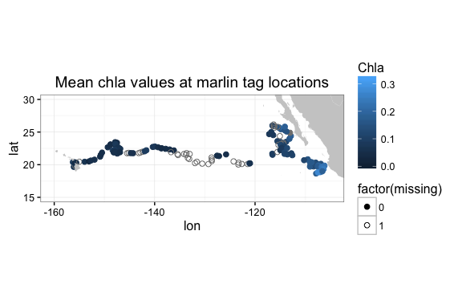

```r
require("ggplot2")
require("mapdata")
# First combine the two dataframes (the input and the output) into one,
# so it will be easy to take into account the locations that didn’t
# retrieve a value.
alldata <- cbind(tagData, swchl)
# adjust the longitudes to be (-180, 180)
alldata$lon <- alldata$lon - 360
# Create a variable that shows if chla is missing
alldata$missing <- is.na(alldata$mean) * 1
# set limits of the map
ylim <- c(15, 30)
xlim <- c(-160, -105)
# get outline data for map
w <- map_data("worldHires", ylim = ylim, xlim = xlim)
# plot using ggplot
z <- ggplot(alldata,aes(x=lon, y=lat)) +
   geom_point(aes(colour=mean, shape=factor(missing)), size=2.) +
   scale_shape_manual(values=c(19,1))
z + geom_polygon(data = w, aes(x=long, y = lat, group = group), fill = "grey80") +
  theme_bw() +
  scale_colour_gradient(limits=c(0.,0.32), "Chla") +
  coord_fixed(1.3, xlim = xlim,  ylim = ylim) + ggtitle("Mean chla values at marlin tag locations")
```

### Comparing with the median

The `xtracto` routine extracts the environment data in a box (defined by `xlen` and `ylen`) around the given location, and calculates statistics of the data in that box. The median chla concentration may make more sense in this situation

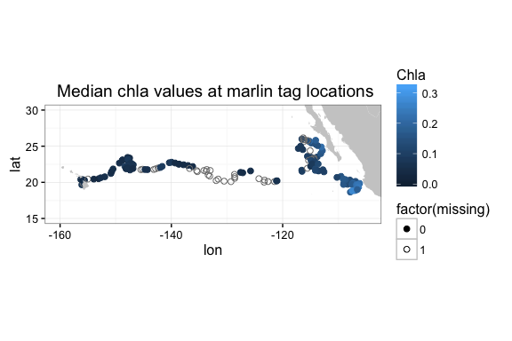

```r
require("ggplot2")
# plot using ggplot
z <- ggplot(alldata, aes(x=lon, y=lat)) +
     geom_point(aes(colour=median, shape=factor(missing)), size=2.) +
     scale_shape_manual(values=c(19, 1))
z + geom_polygon(data = w, aes(x=long, y = lat, group = group), fill = "grey80") +
    theme_bw() +
    scale_colour_gradient(limits=c(0., 0.32), "Chla") +
    coord_fixed(1.3, xlim = xlim, ylim = ylim) + ggtitle(" Median chla values at marlin tag locations")
```

The median chla is smaller than the mean chla (a maximum of 0.273 compared to 0.323).

### Topography data

In addition to satellite data, `xtractomatic` can access topographic data. As an example we extract and plot the water depth (bathymetry) associated with the trackline.

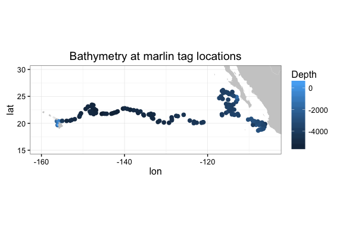

```r
require("xtractomatic")
require("ggplot2")
ylim <- c(15, 30)
xlim <- c(-160, -105)
topo <- xtracto(tagData$lon, tagData$lat, tagData$date, "ETOPO360", .1, .1)
alldata <- cbind(tagData, topo)
alldata$lon <- alldata$lon - 360
z <- ggplot(alldata,aes(x=lon, y=lat)) +
     geom_point(aes(colour=mean), size=2.) +
     scale_shape_manual(values=c(19, 1))
z + geom_polygon(data = w, aes(x=long, y = lat, group = group), fill = "grey80") +
    theme_bw() +
    scale_colour_gradient("Depth") +
    coord_fixed(1.3, xlim = xlim, ylim = ylim) + ggtitle("Bathymetry at marlin tag locations")
```

## Reading in tagged data

The above example uses data already converted to R format, but clearly the utility of the `xtracto` function lies in using it with one’s own dataset. This dataset was read in from a text file called Marlin-tag38606.txt, which is also made available when the `xtractomatic` package is loaded. To be able to refer to this file:

```r
system.file("extdata", "Marlin-tag38606.txt", package = "xtractomatic")
```

The first 5 lines of the file can be viewed:

```r
datafile <- system.file("extdata", "Marlin-tag38606.txt", package = "xtractomatic")
system(paste("head -n5 ", datafile))
```

```
date    lon lat lowLon  higLon  lowLat  higLat
4/23/2003   203.899 19.664  203.899 203.899 19.664  19.664
4/24/2003   204.151 19.821  203.912597  204.389403  18.78051934 20.86148066
4/30/2003   203.919 20.351  203.6793669 204.1586331 18.79728188 21.90471812
5/1/2003    204.229 20.305  203.9943343 204.4636657 18.90440013 21.70559987
```

and read in as follows:

```r
Marlingtag38606 <- read.csv(datafile, head=TRUE, stringsAsFactors = FALSE, sep="\t")
```

[output not shown]

```r
str(Marlingtag38606)
```

```
'data.frame':   152 obs. of  7 variables:
 $ date  : chr  "4/23/2003" "4/24/2003" "4/30/2003" "5/1/2003" ...
 $ lon   : num  204 204 204 204 204 ...
 $ lat   : num  19.7 19.8 20.4 20.3 20.3 ...
 $ lowLon: num  204 204 204 204 204 ...
 $ higLon: num  204 204 204 204 204 ...
 $ lowLat: num  19.7 18.8 18.8 18.9 18.9 ...
 $ higLat: num  19.7 20.9 21.9 21.7 21.7 ...
```

The file Marlingtag38606.txt is a “tab” separated file, not a comma seperated file, so the `sep` option in the `read.csv` function above indicates that to the function, and `stringsAsFactors = FALSE` tells the function not to treat the dates as factors.

To be useful the date field, now formatted for example as `4/23/2003`, needs to be converted to an R date field:

```r
Marlintag38606$date <- as.Date(Marlintag38606$date, format='%m/%d/%Y')
```

The format of the date has to be given because the dates in the file are not in one of the formats recognized by `as.Date`. A small y (%y) indicates the year has 2 digits (97) while a capital Y (%Y) indicates the year has 4 digits (1997). If your file is in the EU format with commas as decimal points and semicolons as field separators then use read.csv2 rather than read.csv.

This dataset includes the range of the 95% confidence interval for both the latitude and the longitude, which are the last four columns of data. In the example above the search “diameter” was read into xtracto was a constant value of 0.2 degrees, but a vector can also be read in. To use the limits given in the file, create the vectors as follows:

```r
xrad <- abs(Marlintag38606$higLon - Marlintag38606$lowLon)
yrad <- abs(Marlintag38606$higLat - Marlintag38606$lowLat)
```

## Using `xtracto_3D`

### Comparing chlorophyll estimates from different satellites

This example extracts a time-series of monthly satellite chlorophyll data for the period 1998-2014 from three different satellites ( SeaWIFS, MODIS and VIIRS ), using the `xtracto_3D` function. The extract is for an area off the coast of California. `xtracto_3D` extracts data in a 3D bounding box where `xpos` has the minimum and maximum longitude, `ypos` has the minimum and maximum latitude, and `tpos` has the starting and ending time, given as “YYY-MM-DD”, describing the bounding box.

First we define the longitude, latitude and temporal boundaries of the box:

```r
xpos <- c(235, 240)
ypos <- c(36, 39)
tpos <- c('1998-01-01', '2014-11-30')
```

The extract will contain data at all of the longitudes, latitudes and times in the requested dataset that are within the given bounds.

If we run the `xtracto_3D` using the full temporal contraints defined above for SeaWiFS we get an error:

```r
require("xtractomatic")
chlSeaWiFS <- xtracto_3D(xpos, ypos, tpos, 'swchlamday')
```

```
[1] "tpos  (time) has elements out of range of the dataset"
[1] "time range in tpos"
[1] "1998-01-01,2014-11-30"
[1] "time range in ERDDAP data"
[1] "1997-09-16,2010-12-16T12:00:00Z"
```

```
Error in xtracto_3D(xpos, ypos, tpos, "swchlamday") :
  Coordinates out of dataset bounds - see messages above
```

The error occurs because the time-range specified is outside of the time-bounds of the requested dataset ( SeaWIFS data stopped in 2010). The error message generated by `xtracto_3D` explains this, and gives the temporal boundaries of the dataset. A simple way to extract to the end of a dataset is to use “last” (see Taking advantage of “last times”):

```r
require("xtractomatic")
require("lubridate")
tpos <- c("1998-01-16", "last")
SeaWiFS <- xtracto_3D(xpos, ypos, tpos, 'swchlamday')
SeaWiFS$time <- as.Date(SeaWiFS$time)
```

A similar extract can be made for the MODIS dataset. We know that the time-range of the MODIS dataset is also smaller than that defined by `tpos`. We can determine the exact bounds of the MODIS dataset by using the `getInfo` function:

```r
require("xtractomatic")
getInfo("mhchlamday")
```

```
[1] "mhchlamday"

dtypename                                                                                 mhchlamday
datasetname                                                                           erdMH1chlamday
longname          Chlorophyll-a, Aqua MODIS, NPP, L3SMI, Global, Science Quality (Monthly Composite)
varname                                                                                  chlorophyll
hasAlt                                                                                         FALSE
latSouth                                                                                       FALSE
lon360                                                                                         FALSE
minLongitude                                                                               -179.9792
maxLongitude                                                                                179.9792
longitudeSpacing                                                                          0.04166667
minLatitude                                                                                -89.97916
maxLatitude                                                                                 89.97918
latitudeSpacing                                                                          -0.04166667
minAltitude                                                                                     <NA>
maxAltitude                                                                                     <NA>
minTime                                                                                   2003-01-16
maxTime                                                                                   2016-05-16
timeSpacing(days)                                                                   30.4326241134752
infoURL                                                             http://oceancolor.gsfc.nasa.gov/
```

which gives us the min and max time of the dataset, which we can be used in the call (or use “last” as above):

```r
require("xtractomatic")
require("lubridate")
tpos <- c("2003-01-16", "last")
MODIS <- xtracto_3D(xpos, ypos, tpos, "mhchlamday")
MODIS$time <- as.Date(MODIS$time)
```

Similarly we can extract data from the VIIRS dataset.

```r
require("xtractomatic")
require("lubridate")
tpos <- c("2012-01-15", "last")
VIIRS <- xtracto_3D(xpos, ypos, tpos, "erdVH2chlamday")
VIIRS$time <- as.Date(VIIRS$time)
```

`xtracto_3d` returns a list of the form:

- extract$data : num [longitude, latitude, time]
- extract$varname : character string with the name of the variable
- extract$datasetname: character string of the ERDDAP dataset ID
- extract$latitude : num [latitude] latitudes of extract
- extract$longitude : num [longitude] longitude of extact
- extract$time : chr [time] times of extract
- extract$altitude : num altitude of extract

in this case the varname is chla, the ERDDAP `datasetID` is erdVH2chlamday, and data contains the data on the grid defined by longitude, latitude and time. The data from the different satellites can be compared by mapping the values for a given time period. To do so we define a helper function `mapFrame` to reshape the data to be used in `ggplot2`.

```r
mapFrame <- function(longitude, latitude, chla) {
  dims <- dim(chla)
  chla <- array(chla, dims[1] * dims[2])
  longitude <- longitude - 360
  chlaFrame <- expand.grid(x=longitude, y=latitude)
  chlaFrame$chla <- chla
  return(chlaFrame)
}
```

and also define a helper function `plotFrame` to plot the data:

```r
plotFrame <- function(chlaFrame, xlim, ylim, title, logplot=TRUE){
  require("mapdata")
  require("ggplot2")
  require("RColorBrewer")
  w <- map_data("worldHires", ylim = ylim, xlim = xlim)
  myplot <- ggplot(data = chlaFrame, aes(x = x, y = y, fill = chla)) +
            geom_raster(interpolate = FALSE) +
            geom_polygon(data = w, aes(x=long, y = lat, group = group), fill = "grey80") +
            theme_bw() + ylab("latitude") + xlab("longitude") +
            coord_fixed(1.3, xlim = xlim, ylim = ylim)
  if (logplot) {
     my.col <- colorRampPalette(rev(brewer.pal(11, "RdBu")))(5.5)
     myplot <- myplot + scale_fill_gradientn(colours = my.col, na.value = NA, limits=c(-2,4.5)) +
               ggtitle(title)
    } else {
     my.col <- colorRampPalette(rev(brewer.pal(11, "RdBu")))((diff(range(chlaFrame$chla, na.rm=TRUE))))
     myplot <- myplot + scale_fill_gradientn(colours = my.col, na.value = NA) +
     ggtitle(title)
  }
  return(myplot)
}
```

We examine chlorophyll in June 2012 a period when VIIRS and MODIS both had data. Starting with VIIRS:

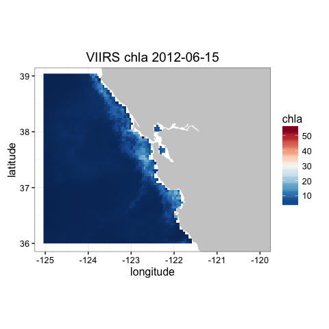

```r
require("lubridate")
xlim <- c(235, 240) - 360
ylim <- c(36, 39)
ttext <- VIIRS$time[month(VIIRS$time) == 6 & year(VIIRS$time) == 2012]
chlaFrame <- mapFrame(VIIRS$longitude, VIIRS$latitude, VIIRS$data[, , month(VIIRS$time) == 6 & year(VIIRS$time) == 2012])
chlaPlot <- plotFrame(chlaFrame, xlim, ylim, paste("VIIRS chla", ttext), logplot=FALSE)
chlaPlot
```

Chlorophyll values are highly skewed, with low values most places and times, and then for some locations very high values. For this reason log(chlorophyll) is usually plotted.

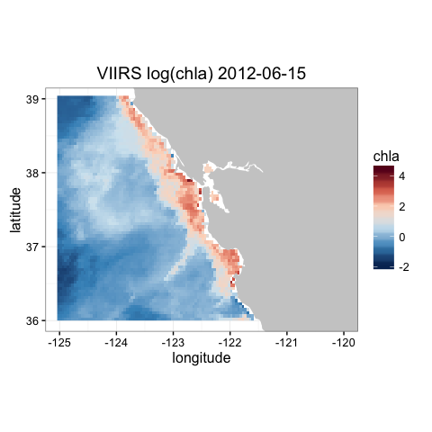

```r
xlim <-c(235, 240) - 360
ylim <-c(36, 39)
chlalogFrame <- mapFrame(VIIRS$longitude, VIIRS$latitude,
                        log(VIIRS$data[, , month(VIIRS$time) == 6 & year(VIIRS$time) == 2012]))
chlalogPlot <- plotFrame(chlalogFrame, xlim, ylim, paste("VIIRS log(chla)", ttext))
chlalogPlot
```

And also for MODIS:

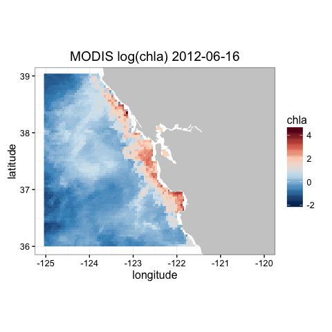

```r
xlim <- c(235, 240) - 360
ylim <- c(36, 39)
ttext <- MODIS$time[month(MODIS$time) == 6 & year(MODIS$time) == 2012]
chlalogFrame <- mapFrame(MODIS$longitude,MODIS$latitude,
                        log(MODIS$data[,,month(MODIS$time) == 6 & year(MODIS$time) == 2012]))
chlalogPlot <- plotFrame(chlalogFrame, xlim, ylim, paste("MODIS log(chla)", ttext))
chlalogPlot
```

SeaWiFS stopped functioning at the end of 2010, so we look at June, 2010:

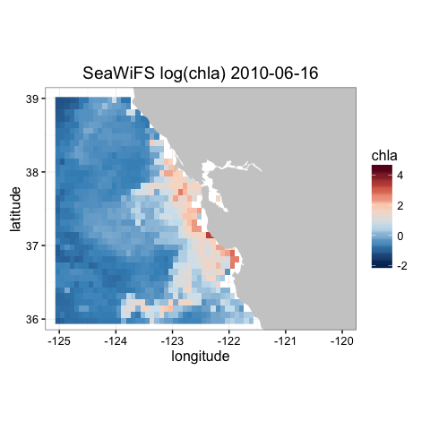

```r
xlim<-c(235,240)-360
ylim<-c(36,39)
ttext<-SeaWiFS$time[month(SeaWiFS$time) == 6 & year(SeaWiFS$time) == 2010]
chlalogFrame<-mapFrame(SeaWiFS$longitude,SeaWiFS$latitude,
                       log(SeaWiFS$data[,,month(SeaWiFS$time) == 6 & year(SeaWiFS$time) == 2010]))
chlalogPlot<-plotFrame(chlalogFrame,xlim,ylim,paste("SeaWiFS log(chla)",ttext))
chlalogPlot
```

We can also look at changes in log(chlorophyll) over time for a given region. We examine a higly productive region just north of San Francisco, with limits (38N, 38.5N) and (123.5W, 123W).

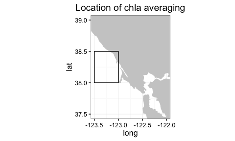

```r
require("ggplot2")
require("mapdata")
xlim1 <- c(-123.5, -123) + 360
ylim1 <- c(38, 38.5)
w <- map_data("worldHires", ylim = c(37.5,39), xlim = c(-123.5, -122.))
z <- ggplot() + geom_polygon(data = w, aes(x=long, y = lat, group = group), fill = "grey80") +
     theme_bw() +
     coord_fixed(1.3, xlim = c(-123.5,-122.), ylim = c(37.5,39))
z + geom_rect(aes(xmin = -123.5, xmax = -123., ymin=38., ymax=38.5), colour="black", alpha=0.) +
    theme_bw() + ggtitle("Location of chla averaging")
```

We define a helper function `chlaAvg` which finds the latitudes and longitudes in the datasets that are closest to the given limits, extracts the subset that is within that region, and then averages over the region to create a time series.

```r
chlaAvg <- function(longitude,latitude,chlaData,xlim,ylim,dStart) {
  xIndex <- xlim
  yIndex <- ylim
  yIndex[1] <- which.min(abs(latitude - ylim[1]))
  yIndex[2] <- which.min(abs(latitude - ylim[2]))
  xIndex[1] <- which.min(abs(longitude- xlim[1]))
  xIndex[2] <- which.min(abs(longitude- xlim[2]))
  tempData <- chlaData[xIndex[1]:xIndex[2], yIndex[1]:yIndex[2],]
  chlaAvg <- apply(tempData, 3, mean, na.rm=TRUE)
  chlaAvg <- ts(chlaAvg, frequency = 12, start = dStart)
return(chlaAvg)
}
```

We use `chlaAvg` to extract the three time series over the region, combine them and plot the result.

```r
require("ggplot2")
require("ggfortify")
# Get both the average, and the average of log transformed chl for each point in the time series
SeaWiFSavg <- chlaAvg(SeaWiFS$longitude, SeaWiFS$latitude, SeaWiFS$data, xlim1, ylim1, c(1998, 1))
SeaWiFSlog <- chlaAvg(SeaWiFS$longitude, SeaWiFS$latitude, log(SeaWiFS$data), xlim1, ylim1, c(1998, 1))
# Run the same steps again for the MODIS and VIIRS datasets
MODISavg <- chlaAvg(MODIS$longitude, MODIS$latitude, MODIS$data, xlim1, ylim1, c(2003, 1))
MODISlog <- chlaAvg(MODIS$longitude, MODIS$latitude, log(MODIS$data), xlim1, ylim1,c(2003, 1))
# run the same for VIIRS
VIIRSavg <- chlaAvg(VIIRS$longitude, VIIRS$latitude, VIIRS$data, xlim1, ylim1,c(2012, 1))
VIIRSlog <- chlaAvg(VIIRS$longitude, VIIRS$latitude, log(VIIRS$data), xlim1, ylim1, c(2012,1))
```

First the raw chla values:

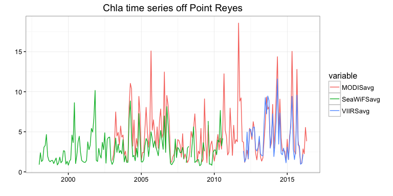

```r
require("ggplot2")
require("ggfortify")
Chla <- cbind(VIIRSavg, MODISavg, SeaWiFSavg)
autoplot(Chla, facets = FALSE) + theme_bw() + ggtitle("Chla time series off Point Reyes")
```

and then log(chla):

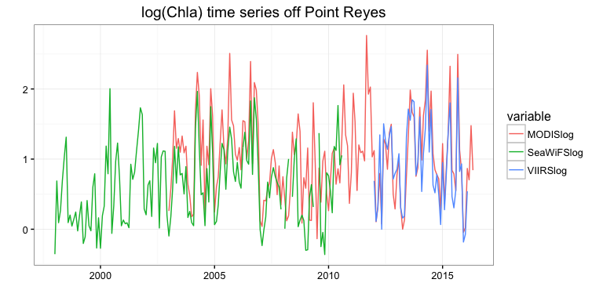

```r
require("ggplot2")
require("ggfortify")
logChla <- cbind(VIIRSlog, MODISlog, SeaWiFSlog)
autoplot(logChla, facets = FALSE) + theme_bw() + ggtitle("log(Chla) time series off Point Reyes")
```

### Upwelling

ERD for many years has produced 6-hourly Bakun upwelling indices at 15 set locations. But suppose you want the values at a different location? To do this we define a function `upwell` that rotates Ekman transport values to obtain the offshore component (upwelling index), and also define a function `plotUpwell` to plot upwelling. `xtracto_3D` can download Ekman transport calculated from Fleet Numerical Meteorlogical and Oceanographic Center (FNMOC) pressure fields:

```r
upwell <- function(ektrx, ektry, coast_angle) {
   pi <- 3.1415927
   degtorad <- pi/180.
   alpha <- (360-coast_angle) * degtorad
   s1 <- cos(alpha)
   t1 <- sin(alpha)
   s2 <- -1 * t1
   t2 <- s1
   perp <- (s1 * ektrx) + (t1 * ektry)
   para <- (s2 * ektrx) + (t2 * ektry)
return(perp/10)
}
```

```r
plotUpwell <- function(upwelling, upDates) {
require("ggplot2")
require("ggfortify")
require("xts")
temp <- xts(upwelling, order.by=upDates)
autoplot(temp) + theme_bw() + ylab("Upwelling")
}
```

We calculate 6-hourly upwelling at (37,-122) for the year 2005 and use the coast angle that ERD uses for (36N , 122W) which is 152 degrees.

```r
require("xtractomatic")
xpos <- c(238, 238)
ypos <- c(37, 37)
tpos <- c("2005-01-01", "2005-12-31")
ektrx <- xtracto_3D(xpos, ypos, tpos, "erdlasFnTran6ektrx")
ektry <- xtracto_3D(xpos, ypos, tpos, "erdlasFnTran6ektry")
upwelling <- upwell(ektrx$data, ektry$data, 152)
```

A plot of the result:

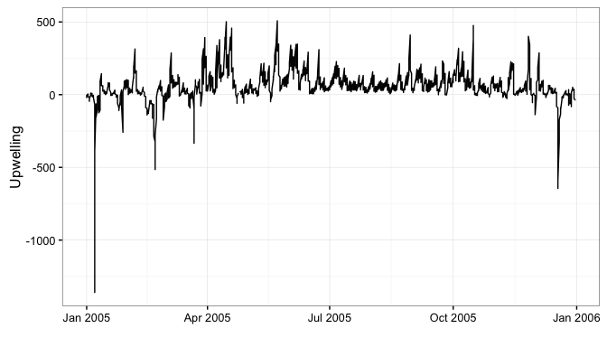

```r
plotUpwell(upwelling, as.Date(ektrx$time))
```

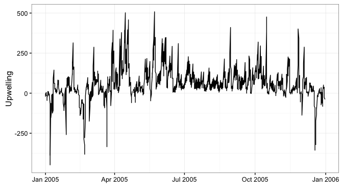

```r
tempUpw <- upwelling
tempUpw[tempUpw < -500] <- NA
plotUpwell(tempUpw, as.Date(ektrx$time))
```

In 2005 there was a large die-off of sea animals and many felt that is was due to an anomalously delayed upwelling. Let’s compare upwelling in 2005 at that location with upwelling in 1977:

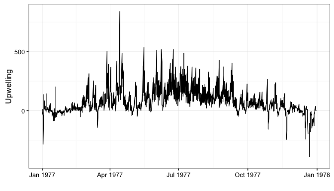

```r
require("xtractomatic")
tpos <- c("1977-01-01", "1977-12-31")
ektrx77 <- xtracto_3D(xpos, ypos, tpos, "erdlasFnTran6ektrx")
ektry77 <- xtracto_3D(xpos, ypos, tpos, "erdlasFnTran6ektry")
upwelling77 <- upwell(ektrx77$data, ektry77$data, 152)
# remove the one big storm at the end
tempUpw <- upwelling77
tempUpw[tempUpw < -500] <- NA
plotUpwell(tempUpw, as.Date(ektrx77$time))
```

While we have not looked at all areas along the coast, at least for this location it is difficult to see upwelling in 2005 as being any more delayed than in 1977 when there was not the same affect on animals.

### Comparisons of Wind Stress

A problem faced when using satellite based estimates of wind stress is that the QuikSCAT based estimates start in 1999-07-21 and end in 2009-11-19, while the ASCAT based estimates start in 2009-10-03 and are ongoing. A comparison of the data over the period of overlap would be of interest.

```r
require("xtractomatic")
xpos <- c(237, 237)
ypos <- c(36, 36)
tpos <- c("2009-10-04", "2009-11-19")
ascat <- xtracto_3D(xpos, ypos, tpos, "erdQAstress3daytauy")
quikscat <- xtracto_3D(xpos, ypos, tpos, "erdQSstress3daytauy")
```

Plotting the result

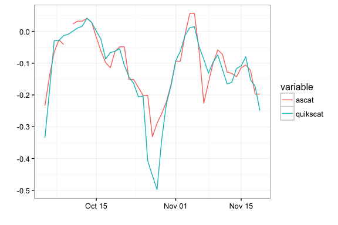

```r
require("ggplot2")
require("ggfortify")
require("xts")
ascatStress <- xts(ascat$data, order.by = as.Date(ascat$time))
quikscatStress <- xts(quikscat$data, order.by = as.Date(quikscat$time))
stressCompare <- cbind(ascatStress, quikscatStress)
colnames(stressCompare) <- c("ascat", "quikscat")
autoplot(stressCompare, facets = FALSE) + theme_bw()
```

While the two wind stress series are close, there is a significant difference in the negative (southward) value on October 28, that is there will be a signifcant difference in the estimated (positive) upwelling value. Combining the series into a longer series would be desirable, but this suggests that there could be problems with inter-year comparisons due to the different sources of the data.

### Taking advantage of “last times”

The ERDDAP server understands a time of “last” as being the last time period available for that dataset, and permits arithmetic using “last”, that is “last-5” is a valid time and will be 5 time periods before the last time (note that since different datasets have different time periods this difference is dataset dependent). For example to extract the last six months of SST from POES AVHRR we look at the monthly agsstmday dataset:

```r
require("xtractomatic")
xpos <- c(235, 240)
ypos <- c(36, 39)
tpos <- c("last-5", "last")
poes <- xtracto_3D(xpos, ypos, tpos, "agsstamday")
```

Plotting the result using faceting in ggplot2:

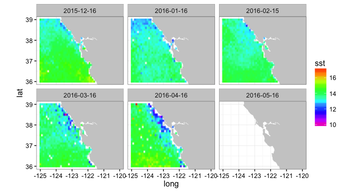

```r
require("ggplot2")
require("reshape2")
require("mapdata")
melt_sst <- function(longitude, latitude, mTime, sst) {
  dimnames(sst) <- list(long = longitude, lat = latitude)
  ret <- melt(sst, value.name = "sst")
  cbind(date = mTime, ret)
}
xpos <- xpos - 360
longitude <- poes$longitude - 360
latitude <- poes$latitude
imon <- 1:6
tmp <- lapply(imon, function(x) melt_sst(longitude, latitude, poes$time[x], poes$data[, , x]))
allmons <- do.call(rbind, tmp)
w <- map_data("worldHires", ylim = ypos, xlim = xpos)
ggplot(data = allmons, aes(x = long, y = lat, fill = sst)) +
    geom_polygon(data = w, aes(x=long, y = lat, group = group), fill = "grey80") +
    geom_raster(interpolate = TRUE) +
    scale_fill_gradientn(colours = rev(rainbow(10)), na.value = NA) +
    theme_bw() +
    coord_fixed(1.3, xlim = xpos, ylim = ypos) +
    facet_wrap(~ date, nrow = 2)
```

### Extracting Multiple, non-consecutive time periods

What if we want to extract data from non-consecutive time periods, for example the last six Decembers for an area? SST was unusually warm off of Catalina Island in Dec 2014, and we show this by comparing the same day in December for six years, 2009-2014:

```r
require("reshape2")
allyears <- NULL
xpos <- c(238, 243)
ypos <- c(30, 35)
for (year in 2009:2014) {
  tpos <- rep(paste(year, '-12-20', sep=""), 2)
  tmp <- xtracto_3D(xpos, ypos, tpos, 'jplMURSST')
#ggplot is sensitve that the grid is absolutely regular
  tmp$latitude <- seq(range(tmp$latitude)[1], range(tmp$latitude)[2], length.out=length(tmp$latitude))
  tmp$longitude <- seq(range(tmp$longitude)[1], range(tmp$longitude)[2], length.out=length(tmp$longitude))
  dimnames(tmp$data) <- list(long = tmp$longitude, lat = tmp$latitude)
  ret <- melt(tmp$data, value.name="sst")
  ret <- cbind(date=tmp$time, ret)
  allyears<-rbind(allyears, ret)
}
allyears$long <- allyears$long - 360
```

Plotting the result using faceting in ggplot2:

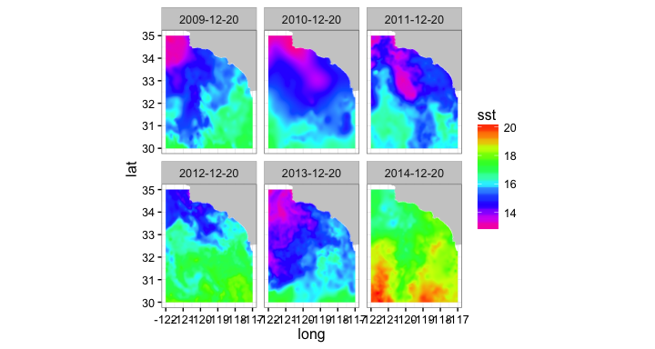

```r
require("ggplot2")
require("mapdata")
xpos <- xpos - 360
#long<-allyears$longitude-360
#lat<-allyears$latitude
coast <- map_data("worldHires", ylim = ypos, xlim = c(-123.5, -120.))
ggplot(data = allyears, aes(x = long, y = lat, fill = sst)) +
  geom_polygon(data = coast, aes(x=long, y = lat, group = group), fill = "grey80") +
  geom_raster(interpolate = TRUE) +
  scale_fill_gradientn(colours = rev(rainbow(10)), na.value = NA) +
  theme_bw() +
  coord_fixed(1.3, xlim = xpos, ylim = ypos) +
  facet_wrap(~ date, nrow = 2)
```

This example uses the MUR (Multi-scale Ultra-high Resolution) SST, a high quality ultra-high resolution SST produced by the MISST project.

## Using `xtractogon`

The `xtractogon` function extracts a time-series of satellite data that are within a user supplied polygon. As an example, the boundary points of the Monterey Bay National Marine Sanctuary are available in the `mbnms` dataset which are loaded with the `xtractomatic` package. The `mbnms` dataset containes two variables, Latitude and Longitude, which define the boundaries of the sanctuary:

```r
require(xtractomatic)
str(mbnms)
```

```
'data.frame':   6666 obs. of  2 variables:
 $ Longitude: num  -123 -123 -123 -123 -123 ...
 $ Latitude : num  37.9 37.9 37.9 37.9 37.9 ...
```

The example below extracts a time-series of monthly VIIRS chlorophyll data within the MBNMS.

```r
require("xtractomatic")
tpos <- c("2014-09-01" ,"2014-10-01")
#tpos <-as.Date(tpos)
xpos <- mbnms$Longitude
ypos <- mbnms$Latitude
sanctchl <- xtractogon(xpos, ypos, tpos, "erdVH2chlamday")
str(sanctchl)
```

```
List of 6
 $ data       : num [1:50, 1:57, 1:2] NA NA NA NA NA NA NA NA NA NA ...
 $ varname    : chr "chla"
 $ datasetname: chr "erdVH2chlamday"
 $ latitude   : num [1:57(1d)] 35.6 35.6 35.6 35.7 35.7 ...
 $ longitude  : num [1:50(1d)] -123 -123 -123 -123 -123 ...
 $ time       : chr [1:2] "2014-09-15" "2014-10-15"
```

The extract (see`str(sanctchl)`) contains two time periods of chlorophyll masked for data only in the sanctuayr boundaries. A plot of the the second time period:

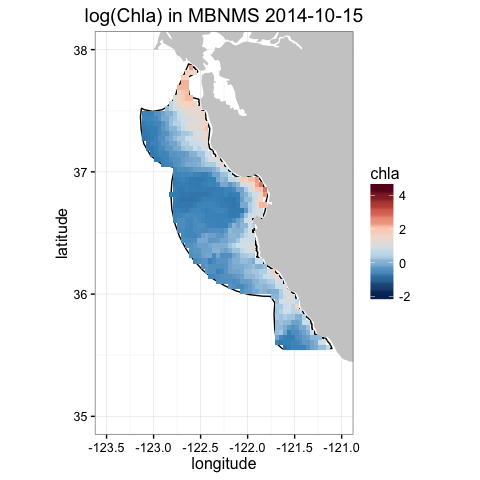

```r
require("RColorBrewer")
require("ggplot2")
require("mapdata")
xlim <- c(-123.5, -121.)
ylim <- c(35, 38)
mbnmsFrame <- mapFrame(sanctchl$longitude+360, sanctchl$latitude, log(sanctchl$data[, , 2]))
my.col <- colorRampPalette(rev(brewer.pal(11, "RdBu")))(5.5)
w <- map_data("worldHires", ylim = ylim, xlim = xlim)
myplot <- ggplot() + geom_path(data=mbnms, aes(x=Longitude, y=Latitude), colour="black")
myplot<-myplot +
        geom_raster(data = mbnmsFrame, aes(x = x, y = y, fill = chla), interpolate = FALSE) +
        geom_polygon(data = w, aes(x=long, y = lat, group = group), fill = "grey80") +
        theme_bw() + scale_fill_gradientn(colours = my.col, na.value = NA, limits=c(-2,4.5)) +
        ylab("latitude") + xlab("longitude") +
        coord_fixed(1.3, xlim = xlim, ylim = ylim) +
        ggtitle(paste("log(Chla) in MBNMS", sanctchl$time[2]))
myplot
```

The MBNMS is famous for containing the Monterey Canyon, which reaches depths of up to 3,600 m (11,800 ft) below surface level at its deepest. `xtractogon` can extract the bathymetry data for the MBNMS from the ETOPO dataset:

```r
require("xtractomatic")
tpos <- c("2014-09-01", "2014-10-01")
#tpos <-as.Date(tpos)
xpos <- mbnms$Longitude
ypos <- mbnms$Latitude
bathy <- xtractogon(xpos, ypos, tpos, "ETOPO180")
str(bathy)
```

```
List of 3
 $ data     : num [1:123, 1:141, 1] NA NA NA NA NA NA NA NA NA NA ...
 $ latitude : num [1:141(1d)] 35.5 35.6 35.6 35.6 35.6 ...
 $ longitude: num [1:123(1d)] -123 -123 -123 -123 -123 ...
```

Mapping the data to show the canyon:

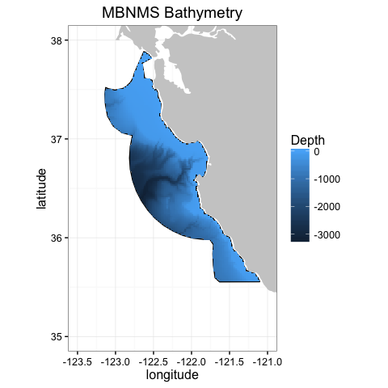

```r
require("ggplot2")
require("RColorBrewer")
require("mapdata")
xlim <- c(-123.5, -121.)
ylim <- c(35, 38)
mbnmsFrame <- mapFrame(bathy$longitude+360, bathy$latitude, bathy$data[,,1])
w <- map_data("worldHires", ylim = ylim, xlim = xlim)
myplot <- ggplot() + geom_path(data=mbnms, aes(x=Longitude, y=Latitude), colour="black")
myplot <- myplot + geom_raster(data = mbnmsFrame, aes(x = x, y = y, fill = chla), interpolate = FALSE) +
         geom_polygon(data = w, aes(x=long, y = lat, group = group), fill = "grey80") +
         theme_bw() + scale_fill_gradient(na.value = NA, name ="Depth") +
         ylab("latitude") + xlab("longitude") +
         coord_fixed(1.3, xlim = xlim, ylim = ylim) + ggtitle("MBNMS Bathymetry")
myplot
```

## What happens when you request an extract

When you make an `xtractomatic` request, particularly for track data using the `xtracto` function, it is important to understand what is extracted, because the remote dataset requested likely will have a different temporal and spatial resolution then the local dataset.

Specifically, let `longitude`, `latitude` and `time` be the coordinate system of the remote ERDDAP dataset, and let `xpos`, `ypos` and `tpos` be the bounds of a request. Then the ERDDAP request is based on the nearest grid point of the ERDDAP dataset:

`latitude[which.min(abs(latitude - ypos[1]))]` # minimum latitude

`latitude[which.min(abs(latitude - ypos[2]))]` # maximum latitude

`longitude[which.min(abs(longitude- xpos[1]))]` # minimum longitude

`longitude[which.min(abs(longitude - xpos[2]))]` # maximum longitude

`isotime[which.min(abs(time - tpos[1]))]` # minimum time

`isotime[which.min(abs(time - tpos[2]))]` # maximum time

where `tpos` and `time` have been converted to an R date format so that it is a number rather than a string. For example, the FNMOC 6-hourly Ekman transports are on a 1-degree grid. A request for the data at a longitude of 220.2 and a latitude of 38.7 will return the result at a longtiude of 220 and a latitude of 39.

## Selecting a dataset

As seen in the examples above, the functions `xtractomatic`, `xtracto`, `xtracto_3D`, and `xtractogon` all use the parameter dtype to specify the combination of dataset and parameter to use. The datasets accessed by `xtractomatic` are a subset of the almost 900 datasets available on ERD’s ERDDAP server at http://coastwatch.pfeg.noaa.gov/erddap/index.html. The datasets chosen to be accessible by `xtractomatic` are those that are the most useful to the majority of our users. This version of `xtractomatic` accesses 153 datasets. Information about a particular dataset is availble via the `getInfo` function. `getInfo` takes either the numbered value of a dataset, or the datatype name (the parameter dtypename), which is the first information returned by `getInfo`. `getInfo` does not return the number of the dataset, the use of the dtypename is encouraged rather than the number associated with the dataset. It is strongly recommended that dtype not be passed as a number, as the numbers can change and will not be used in the next version.

There are a large number of temporally composited datasets available. The temporal composite time interval is usually indicated in the dtypename (for example “phssta8day” is an 8-day composite), datasetname (for example “erdPHssta8day”) and longname (for example “SST, Pathfinder Ver 5.0, Day and Night, Global, Science Quality (8 Day Composite)”) variables associated with a dataset. The time interval between data points in the time-series is indicated by the timespacing parameter. For example note the difference in timespacing for dtypename=“mhchla8day” and dtypename=“mbchla8day”, which are both 8-day composites.

```r
getInfo("mhchla8day")
```

```
[1] "mhchla8day"

dtypename                                                                               mhchla8day
datasetname                                                                         erdMH1chla8day
longname          Chlorophyll-a, Aqua MODIS, NPP, L3SMI, Global, Science Quality (8 Day Composite)
varname                                                                                chlorophyll
hasAlt                                                                                       FALSE
latSouth                                                                                     FALSE
lon360                                                                                       FALSE
minLongitude                                                                             -179.9792
maxLongitude                                                                              179.9792
longitudeSpacing                                                                        0.04166667
minLatitude                                                                              -89.97916
maxLatitude                                                                               89.97918
latitudeSpacing                                                                        -0.04166667
minAltitude                                                                                   <NA>
maxAltitude                                                                                   <NA>
minTime                                                                                 2003-01-05
maxTime                                                                                 2016-06-21
timeSpacing(days)                                                                 7.94495412844037
infoURL                                                           http://oceancolor.gsfc.nasa.gov/
```

```r
getInfo("mbchla8day")
```

```
[1] "mbchla8day"

dtypename                                                              mbchla8day
datasetname                                                         erdMBchla8day
longname          Chlorophyll-a, Aqua MODIS, NPP, Pacific Ocean (8 Day Composite)
varname                                                               chlorophyll
hasAlt                                                                       TRUE
latSouth                                                                     TRUE
lon360                                                                       TRUE
minLongitude                                                                  120
maxLongitude                                                                  320
longitudeSpacing                                                            0.025
minLatitude                                                                   -45
maxLatitude                                                                    65
latitudeSpacing                                                             0.025
minAltitude                                                                     0
maxAltitude                                                                     0
minTime                                                                2005-12-29
maxTime                                                                2016-07-20
timeSpacing(days)                                                1.13935574229692
infoURL                    http://coastwatch.pfeg.noaa.gov/infog/MB_chla_las.html
```

The difference is that the latter dataset (`mbchla8day`) is a running 8-day composite, so there is a value for every day, while the former dataset (`mhchla8day`) calculates composites for non-overlapping 8-day periods.

The `searchData` function can be used to search for a subset of that satisfy certain criteria. `searchData` requires a list of lists, where each element of the first item of the list has to be one of `dtypename, datasetname, longname, varname`, and the other is the string to search for in that field. For example to find all of the datasets that have a `varname` that contains `chl` and a `datasetname` that contains `mday` (most monthly datasets have `mday` in their name):

```r
list1 <- list("varname", "chl")
list2 <- list("datasetname", "mday")
mylist <- list(list1, list2)
searchData(mylist)
```

```
[1] "mhchlamday"

dtypename                                                                                mhchlamday
datasetname                                                                          erdMH1chlamday
longname         Chlorophyll-a, Aqua MODIS, NPP, L3SMI, Global, Science Quality (Monthly Composite)
varname                                                                                 chlorophyll
hasAlt                                                                                        FALSE
latSouth                                                                                      FALSE
lon360                                                                                        FALSE
minLongitude                                                                              -179.9792
maxLongitude                                                                               179.9792
longitudeSpacing                                                                         0.04166667
minLatitude                                                                               -89.97916
maxLatitude                                                                                89.97918
latitudeSpacing                                                                         -0.04166667
minAltitude                                                                                    <NA>
maxAltitude                                                                                    <NA>
minTime                                                                                  2003-01-16
maxTime                                                                                  2016-05-16
timeSpacing                                                                        30.4326241134752
infoURL                                                            http://oceancolor.gsfc.nasa.gov/

[1] "swchlamday"

dtypename                                                                     swchlamday
datasetname                                                                erdSWchlamday
longname         Chlorophyll-a, Orbview-2 SeaWiFS, Global (Monthly Composite) DEPRECATED
varname                                                                      chlorophyll
hasAlt                                                                              TRUE
latSouth                                                                            TRUE
lon360                                                                              TRUE
minLongitude                                                                           0
maxLongitude                                                                         360
longitudeSpacing                                                              0.08335263
minLatitude                                                                          -90
maxLatitude                                                                           90
latitudeSpacing                                                               0.08337193
minAltitude                                                                            0
maxAltitude                                                                            0
minTime                                                                       1997-09-16
```

[output cut: 76 more lines]

```
hasAlt                                                                                    TRUE
latSouth                                                                                 FALSE
lon360                                                                                   FALSE
minLongitude                                                                        -180.03375
maxLongitude                                                                        -110.00625
longitudeSpacing                                                                        0.0075
minLatitude                                                                           -0.10875
maxLatitude                                                                           89.77125
latitudeSpacing                                                                         0.0075
minAltitude                                                                                  0
maxAltitude                                                                                  0
minTime                                                                             2015-02-25
maxTime                                                                             2016-06-16
timeSpacing                                                                               <NA>
infoURL                                                                                   <NA>
```

which returns among others the three chlorophyll datasets extracted in the `xtracto_3D` section. Note that since the function requires a “list of lists”, if only doing the first search the code would be:

`mylist <- list(list("varname", "chl"))`

`searchData(myList)`

`searchData` iteratively refines the matches in the order given by the list of list, thus it can be viewed as doing a logical “AND” on the matches.

The longname of a dataset often contains a lot of this information. Alternatively you can generate a list of the datasetname and longname of all of the datasets accessed by `xtractomatic` (we only show the first five lines of output):

```r
# to actually use do:
# cat(paste(xtractomatic:::erddapStruct[,1], ':' , xtractomatic:::erddapStruct[,3], "\n"))
cat(paste0(xtractomatic:::erddapStruct[1:5,1], ': ' , xtractomatic:::erddapStruct[1:5,3], "\n"))
```

```
ETOPO180: Topography, ETOPO1, 0.0166667 degrees, Global (longitude -180 to 180), (Ice Sheet Surface)
 ETOPO360: Topography, ETOPO1, 0.0166667 degrees, Global (longitude 0 to 360), (Ice Sheet Surface)
 atsstnhday: SST, POES AVHRR, LAC, West US, Nighttime (Hourly)
 atssdhday: SST, POES AVHRR, LAC, West US, Daytime (Hourly)
 atssta1day: SST, POES AVHRR, LAC, West US, Day and Night (1 Day Composite)
```

and then use `getInfo` with the datasetname to see all of the information on that dataset

### Topographic datasets

`xtractomatic` can extract data from two topographic datasets (ETOPO) , with dtypename of “ETOPO180” and “ETOPO360”, which have longitudes ranging from -180 to 180 and 0 to 360 respectively. Currently the `getInfo` and `searchData` commands do not work with these two datasets, but `xtracto`, `xtracto_3D`, and `xtractogon` do. All of these routines require input of a time vector (tpos). The bathymetry datasets are timeless so it does not matter what you input for this parameter, however, it must be given.

## What has Changed and Steps Going Forward

In this and all past version of `xtractomatic`, information about the datasets was built into the functions. In the present case the dataset information is stored in a dataframe called `erddapStruct` which is auotmatically loaded when you loaded the package.

This has the disadvantage that it is tied to specific datasets and a specifc ERDDAP server, rather than working with any dataset served by any ERDDAP.

The dataset was specified by the `dtype`, which could be either a number or a character string, and references the information in that dataframe. The `dtype` names in this version for the most part are same, **BUT THE `dtype` NUMBERS HAVE CHANGED**. If you have used `xtractomatic` before you need to check that the `dtype` information that you are passing is what you think it is. You can do this using the supplied `getInfo` or `searchData` functions or peruse the `erddapStruct` dataframe. There are many more datasets available in this version, adn now “last” can be used as time to get the last time period available for that dataset.

### `dtype` as number is deprecated

It is strongly recommended that you move away from passing `dtype` as a number, as the numbers can change and will not be in the next version. Any ERDDAP dataset has an ERDDAP “dataset ID”, as well one or more variables associated with that “dataset ID”. Some datasets, such as the ASCAT winds have multiple variables associated with the dataset:

http://coastwatch.pfeg.noaa.gov/erddap/griddap/erdQAstress1day.html.

This information is contained in `erddapStruct$datasetname` and `erddapStruct$varname`. Since a single dataset may have more than one variable, `dtype` as character string is a way to have a unique dataset id and variable name in a single variable. In the next version, no information about the datasets will be built into the package, and `xtractomatic` will rely on the search and query capabilities of ERDDAP. Then the request will be based on a list of the form `c(dataset id, varname1, varname2)`. This is the approach being used in the ROpenSci projects `rnoaa` and `rerddap`, and we will be making use of parts their code.